# MM2 HW7

RyanGallagher

2023-04-17

##### Read the grip data. It consists of 2 treatments (trt), 2 genders (gender), and 3 measurement occasions (time=1,2,3), a baseline covariate (x), and a response variable (y).

### 1.) Fit a marginal model for repeated measures including trt, gender, time, and x. Use the unstructured covariance for errors. Treat trt, gender, and time as categorical variables. State your model and assumptions.

*SAS Code*:

```
/* I think we can use both glimmix and mix */
proc glimmix data=grip;
    class trt gender time;
    model y=trt gender time x / solution ddfm=kr;
    random _residual_ / subject=subject type=un vcorr;
run;

proc mixed data=grip;
  class trt gender time;
  model y = trt gender time x / solution;
  repeated time / type=un subject=subject;
run;
```

### 2.) Test whether there is an interaction between time and the other 3 predictor variables.

SAS CODE:

```
proc mixed data=grip;
    class trt gender time;
    model y=trt|time gender|time x|time / solution;
    repeated time / type=un subject=subject;
run;
```

SAS OUTPUT:

```
                                          Standard
Effect       Gender  trt  time  Estimate     Error    DF  t Value  Pr > |t|

Intercept                        64.1267   20.1602    63     3.18    0.0023
trt                  1            2.0622    9.3901    63     0.22    0.8269
trt                  2                 0         .     .      .       .
time                      1      -2.3002   20.3533    63    -0.11    0.9104
time                      2      20.6555   12.5269    63     1.65    0.1041
time                      3            0         .     .      .       .
trt*time             1    1      -2.4383    9.4753    63    -0.26    0.7978
trt*time             1    2      -6.2186    5.9195    63    -1.05    0.2975
trt*time             1    3            0         .     .      .       .
trt*time             2    1            0         .     .      .       .
trt*time             2    2            0         .     .      .       .
trt*time             2    3            0         .     .      .       .
Gender       F                  -26.1487   14.1067    63    -1.85    0.0685
Gender       M                         0         .     .      .       .
Gender*time  F            1      -9.2879   14.2404    63    -0.65    0.5166
Gender*time  F            2     -16.5809    8.7703    63    -1.89    0.0633
Gender*time  F            3            0         .     .      .       .
Gender*time  M            1            0         .     .      .       .
Gender*time  M            2            0         .     .      .       .
Gender*time  M            3            0         .     .      .       .
x                                 0.7162   0.09969    63     7.18    <.0001
x*time                    1      0.05515    0.1006    63     0.55    0.5856
x*time                    2     -0.04048   0.06184    63    -0.65    0.5152
x*time                    3            0         .     .      .       .
```

We find that there is no intercation between time and any of the other 3 predictor variables (however Gender=F and time=2 is very close to significance).

### 3) Plot a boxplot of residuals for gender. What did you observe?

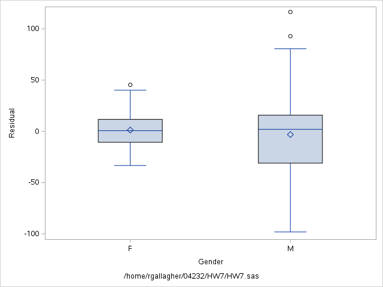

```r
knitr::include_graphics("/Users/ryangallagher/Desktop/MedicalCollegeofWisconsin/BIOS_04232_MM2/SGPlot.png")
```

We find that the Female residuals are relatively normal, where the Male residuals are quite skewed (likely as a result of two large outliars)

### 4) Base on your observation in (3), what is your recommendation? Fit a marginal model based on your recommendation. State your model and assumptions.

I decided to try a log transformation on y. This produces the box plot:

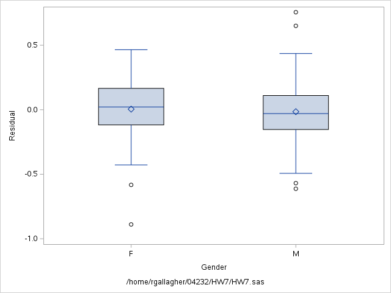

```r
knitr::include_graphics("/Users/ryangallagher/Desktop/MedicalCollegeofWisconsin/BIOS_04232_MM2/SGPlot1.png")
```

Here is a marginal model using the SAS code:

```
data grip2;
    set grip;
    y_prime = log(y);
run;

proc mixed data=grip2;
  class trt gender time;
  model y_prime = trt gender time x / ddfm=kr solution residual outp=residuals2;
  repeated time / type=un subject=subject;
run;
```

### 5) Based on your model in (4), test whether time=1 and time=2 are equal.

SAS INPUT:

```
proc mixed data=grip2;
    class trt gender time;
    model y_prime = trt gender time x / ddfm=kr solution;
    repeated time / type=un subject=subject;
    lsmeans time / diff cl;
run;
```

SAS OUTPUT:

```
                     Differences of Least Squares Means

                                 Standard
  Effect  time  _time  Estimate     Error    DF  t Value  Pr > |t|   Alpha

  time    1     2      -0.04332   0.02805  64.2    -1.54    0.1274    0.05
  time    1     3      -0.02452   0.03112  61.3    -0.79    0.4339    0.05
  time    2     3       0.01880   0.02118  57.9     0.89    0.3784    0.05

                    Differences of Least Squares Means

                 Effect  time  _time     Lower       Upper

                 time    1     2      -0.09936     0.01272
                 time    1     3      -0.08675     0.03771
                 time    2     3      -0.02360     0.06120
```

Thus, we see that the difference between time=1 and time=2 are not significantly different since the p_val > 0.05. We can also see that their CI for difference is [-0.09936, 0.01272], which overlaps 0. This means that we cannot confidently say that the difference between time 1 and time 2 isn’t 0.